# Predict Prices for Your Dream House

STAT 420, Summer 2019, Zhenzhou Yang (zy29), Swan Htun (swanh2), Mike Kramer (mkramer4)

7/16/2019

# Introduction

## Overview

In this project, we plan to find a suitable linear model to predict the prices of residential houses locating in Ames, Iowa, based on their attributes provided. This model is meaningful that the customers who want to buy a new house may rely on it to have a rough estimation.

In this project, many of the topics will be included, some of them will be:

- Multiple linear regression
- Outlier diagnostics
- Model building
- Model selection

## Dataset Introduction

### Source

The `Ames Housing dataset` we use in this project is provided by Dean De Cock from Truman State University for [`Kaggle competition`](https://www.kaggle.com/c/house-prices-advanced-regression-techniques/data).

### Introduction

The origin dataset mainly includes the sale of individual residential houses in Ames, Iowa from 2006 to 2010.

It contains 2919 observations with 23 nominal, 23 ordinal, 14 discrete and 20 continuous variables, which are directly related to property sales. And we just use half of it which contains 1460 observations and split the data by half into our train and test dataset.

In our project, we choose the variables which we think have significant influence in affecting the price of a house to somplify the data and try to reduce the collinearity between different predictors at beginning:

- **SalePrice**: the property’s sale price in dollars. This is our target to predict.
- **LotArea**: Lot size in square feet.
- **MSZoning**: Identifies the general zoning classification of the sale. It has following types:
  - A: Agriculture
  - C: Commercial
  - FV: Floating Village Residential
  - I: Industrial
  - RH: Residential High Density
  - RL: Residential Low Density
  - RP: Residential Low Density Park
  - RM: Residential Medium Density
- **LotShape**: General shape of property. It has the following levels:
  - Reg: Regular
  - IR1: Slightly irregular
  - IR2: Moderately Irregular
  - IR3: Irregular
- **OverallQual**: Overall material and finish quality. It is an ordinal categorical variable range from 1 to 10 in origin data, which indicating the quality from very poor to very excellent.
- **YearBuilt**: Original construction date.
- **TotalBsmtSF**: Total square feet of basement area.
- **LowQualFinSF**: Low quality finished square feet (all floors).
- **BedroomAbvGr**: Bedrooms above grade (does NOT include basement bedrooms).
- **FullBath**: Full bathrooms above grade.
- **GarageArea**: Size of garage in square feet.

### Data

In this section, we will take a look at the data which has been modified by us for the project.

- Train data

```r
library(readr)
data_raw = read_csv("house price.csv")

# split the data
set.seed(51)
train_idx = sample(1 : nrow(data_raw), nrow(data_raw) / 2)
test_idx = setdiff(seq(1 : nrow(data_raw)), train_idx)

train_raw = data_raw[train_idx,]
test_raw = data_raw[test_idx,]

# select variables we want to use
train = subset(train_raw, select = c("SalePrice", "LotArea", "MSZoning", "LotShape", "OverallQual", "YearBuilt", "TotalBsmtSF", "LowQualFinSF", "BedroomAbvGr", "FullBath", "GarageArea"))

# show a few lines
head(train, 5)
```

```
## # A tibble: 5 x 11
##   SalePrice LotArea MSZoning LotShape OverallQual YearBuilt TotalBsmtSF
##       <dbl>   <dbl> <chr>    <chr>          <dbl>     <dbl>       <dbl>
## 1    131500    4435 RM       Reg                6      2003         848
## 2    184100    7750 RL       Reg                8      2002         408
## 3    135000    9600 RL       Reg                5      1949         845
## 4    120500    9000 RL       Reg                4      1971         864
## 5    109900    7200 RL       Reg                4      1950           0
## # … with 4 more variables: LowQualFinSF <dbl>, BedroomAbvGr <dbl>,
## #   FullBath <dbl>, GarageArea <dbl>
```

```r
# let's take a galance at the response variable
head(train$SalePrice, 10)
```

```
##  [1] 131500 184100 135000 120500 109900 141000 229456 133000 209500 140000
```

- Test data

```r
# select variables we want to use
test = subset(test_raw, select = c("SalePrice", "LotArea", "MSZoning", "LotShape", "OverallQual", "YearBuilt", "TotalBsmtSF", "LowQualFinSF", "BedroomAbvGr", "FullBath", "GarageArea"))

# show a few lines
head(test, 5)
```

```
## # A tibble: 5 x 11
##   SalePrice LotArea MSZoning LotShape OverallQual YearBuilt TotalBsmtSF
##       <dbl>   <dbl> <chr>    <chr>          <dbl>     <dbl>       <dbl>
## 1    208500    8450 RL       Reg                7      2003         856
## 2    223500   11250 RL       IR1                7      2001         920
## 3    140000    9550 RL       IR1                7      1915         756
## 4    307000   10084 RL       Reg                8      2004        1686
## 5    200000   10382 RL       IR1                7      1973        1107
## # … with 4 more variables: LowQualFinSF <dbl>, BedroomAbvGr <dbl>,
## #   FullBath <dbl>, GarageArea <dbl>
```

```r
# let's take a galance at the response variable
head(test$SalePrice, 10)
```

```
##  [1] 208500 223500 140000 307000 200000 118000 345000 149000 159000 325300
```

# Methods

## Data Checking

**(1)** First of all, we will check the validality of our data and omit the missing data.

```r
# train set
sum(is.na(train))
```

```
## [1] 0
```

```r
# test set
sum(is.na(test))
```

```
## [1] 0
```

It seems that our data set is very good! There is no missing data in it.

**(2)** The next step is to convert our categorical variables into factor.

```r
# train set
train$MSZoning = as.factor(train$MSZoning)
train$LotShape = as.factor(train$LotShape)

# test set
test$MSZoning = as.factor(test$MSZoning)
test$LotShape = as.factor(test$LotShape)
```

And also, since `OverallQual` has 10 levels which maybe too complicated for us to use, we just modify it into three different levels, the original level 1-3 will be **poor**, level 4-7 will be **average**, the rest, level 8-10, will be **excellent**.

```r
# train set
train$OverallQual[train$OverallQual == 3 | train$OverallQual == 2 | train$OverallQual == 1] = "poor"
train$OverallQual[train$OverallQual == 4 | train$OverallQual == 5 | train$OverallQual == 6 | train$OverallQual == 7] = "average"
train$OverallQual[train$OverallQual == 8 | train$OverallQual == 9 | train$OverallQual == 10] = "excellent"

train$OverallQual = as.factor(train$OverallQual)

# test set
test$OverallQual[test$OverallQual == 3 | test$OverallQual == 2 | test$OverallQual == 1] = "poor"
test$OverallQual[test$OverallQual == 4 | test$OverallQual == 5 | test$OverallQual == 6 | test$OverallQual == 7] = "average"
test$OverallQual[test$OverallQual == 8 | test$OverallQual == 9 | test$OverallQual == 10] = "excellent"

test$OverallQual = as.factor(test$OverallQual)
```

**(3)** Then, we will to check the distribution of our target – `SalePrice`.

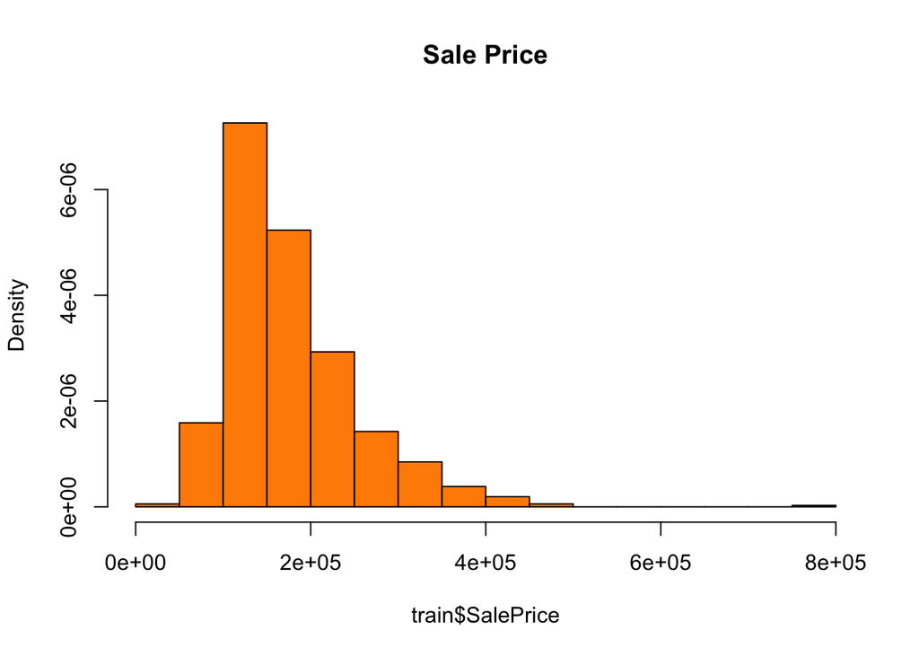

```r
hist(train$SalePrice, col = 'darkorange', main = 'Sale Price', prob = TRUE)
```

It seems that the `SalePrice` is right skewed, so we will try to make some transformations to make it look better.

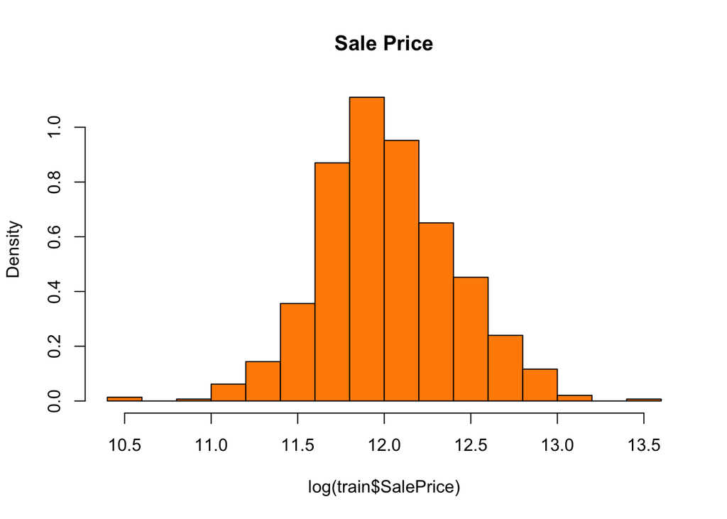

```r
hist(log(train$SalePrice), col = 'darkorange', main = 'Sale Price', prob = TRUE)
```

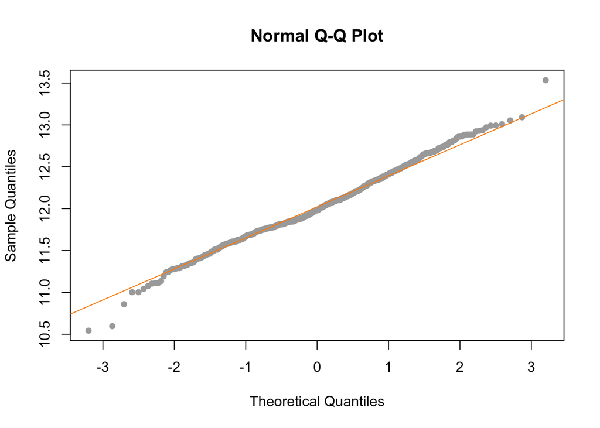

```r
qqnorm(log(train$SalePrice), col = "darkgrey", pch = 20, cex= 1.25)
qqline(log(train$SalePrice), col = "darkorange")
```

After the log transformation, the distribution looks much better now.

## Predictor Choosing

We first modify the factor variables into numeric ones to check the correlation between each variables.

```r
p = train$OverallQual

# convert variables
train$MSZoning = as.numeric(train$MSZoning)
train$LotShape = as.numeric(train$LotShape)
train$OverallQual = as.numeric(train$OverallQual)

# check correlation
round(cor(train), 2)
```

```
##              SalePrice LotArea MSZoning LotShape OverallQual YearBuilt
## SalePrice         1.00    0.21    -0.19    -0.27        0.43      0.54
## LotArea           0.21    1.00    -0.03    -0.17        0.03      0.01
## MSZoning         -0.19   -0.03     1.00     0.06       -0.10     -0.33
## LotShape         -0.27   -0.17     0.06     1.00       -0.10     -0.24
## OverallQual       0.43    0.03    -0.10    -0.10        1.00      0.21
## YearBuilt         0.54    0.01    -0.33    -0.24        0.21      1.00
## TotalBsmtSF       0.61    0.25    -0.10    -0.17        0.31      0.40
## LowQualFinSF     -0.04    0.02     0.05    -0.03       -0.03     -0.13
## BedroomAbvGr      0.17    0.12    -0.01    -0.03       -0.08     -0.06
## FullBath          0.56    0.13    -0.21    -0.14        0.19      0.47
## GarageArea        0.61    0.19    -0.22    -0.16        0.32      0.49
##              TotalBsmtSF LowQualFinSF BedroomAbvGr FullBath GarageArea
## SalePrice           0.61        -0.04         0.17     0.56       0.61
## LotArea             0.25         0.02         0.12     0.13       0.19
## MSZoning           -0.10         0.05        -0.01    -0.21      -0.22
## LotShape           -0.17        -0.03        -0.03    -0.14      -0.16
## OverallQual         0.31        -0.03        -0.08     0.19       0.32
## YearBuilt           0.40        -0.13        -0.06     0.47       0.49
## TotalBsmtSF         1.00        -0.05         0.01     0.32       0.47
## LowQualFinSF       -0.05         1.00         0.01     0.03      -0.02
## BedroomAbvGr        0.01         0.01         1.00     0.36       0.05
## FullBath            0.32         0.03         0.36     1.00       0.38
## GarageArea          0.47        -0.02         0.05     0.38       1.00
```

```r
# convert back
train$MSZoning = as.factor(train$MSZoning)
train$LotShape = as.factor(train$LotShape)
train$OverallQual = as.factor(train$OverallQual)

# rename back the factor variables
levels(train$LotShape) = c("IR1", "IR2", "IR3", "Reg")
levels(train$MSZoning) = c("C (all)", "FV", "RH", "RL", "RM")
levels(train$OverallQual) = c("average", "excellent", "poor")
```

From the table above, we do not find any significant colliearity between different variables. We can choose all of them together for fitting.

## Model Fitting

Before we create any models, we prefer to define some functions we may use later first and import the packages we need.

```r
library(lmtest)
library(MASS)
library(faraway)
library(knitr)
library(kableExtra)

# Fitted versus Residuals Plot
plot_fitted_resid = function(model, pointcol = "darkgrey", linecol = "darkorange") {
  plot(fitted(model), resid(model),
       col = pointcol, pch = 20, cex = 1.25,
       xlab = "Fitted", ylab = "Residuals")
  abline(h = 0, col = linecol, lwd = 2)
}

# Q-Q plot
plot_qq = function(model, pointcol = "darkgrey", linecol = "darkorange") {
  qqnorm(resid(model), col = pointcol, pch = 20, cex = 1.25)
  qqline(resid(model), col = linecol, lwd = 2)
}

# bptest
get_bp_decision = function(model, alpha = 0.05) {
  decide = unname(bptest(model)$p.value < alpha)
  ifelse(decide, "Reject", "Fail to Reject")
}

# shapiro wilk test
get_sw_decision = function(model, alpha = 0.05) {
  decide = unname(shapiro.test(resid(model))$p.value < alpha)
  ifelse(decide, "Reject", "Fail to Reject")
}

# LOOCV_RMSE
get_loocv_rmse = function(model) {
  sqrt(mean((resid(model) / (1 - hatvalues(model))) ^ 2))
}

# ajusted R2
get_adj_r2 = function(model) {
  summary(model)$adj.r.squared
}

# average percentage error
get_avg_err = function(actual, predicted) {
  mean(abs(predicted - actual) / actual)
}
```

### Candidate Models

**(1)** Firstly, we will start with an intersection model with all possible two-way interaction between predictors and an additive model with all possible predictors.

```r
model_add = lm(SalePrice ~ ., data = train)
model_inter = lm(SalePrice ~ . ^ 2, data = train)
```

**(2)** We will also try to find some models with transformed variables。

As we analyzed before, after the log transformation, the SalePrice will be more normalized.

```r
log_add = lm(log(SalePrice) ~ ., data = train)
log_inter = lm(log(SalePrice) ~ . ^ 2, data = train)
```

**(3)** Then, we will check the realtionship between `SalePrice` and each numerical predictors.

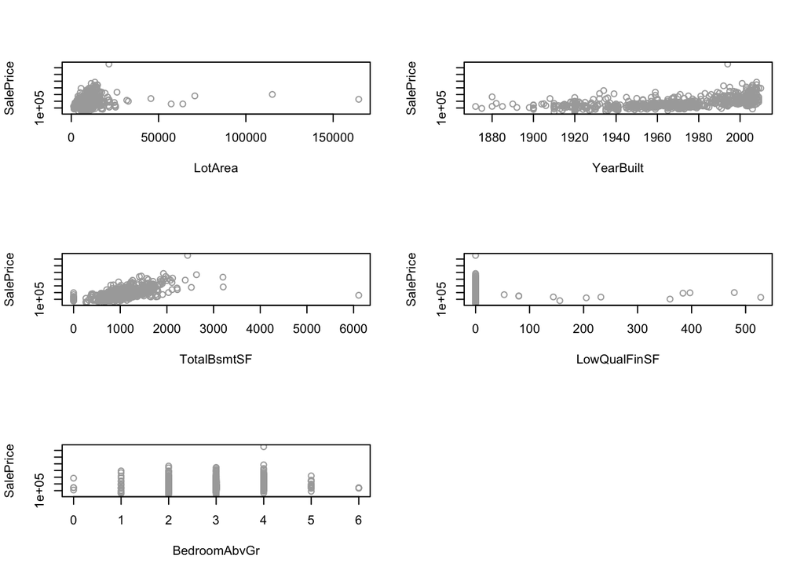

```r
par(mfrow = c(3, 2))
plot(SalePrice ~ LotArea, data = train, col = "darkgrey")
plot(SalePrice ~ YearBuilt, data = train, col = "darkgrey")
plot(SalePrice ~ TotalBsmtSF, data = train, col = "darkgrey")
plot(SalePrice ~ LowQualFinSF, data = train, col = "darkgrey")
plot(SalePrice ~ BedroomAbvGr, data = train, col = "darkgrey")
```

We try to use some transformations to make the plot looks like more linearly.

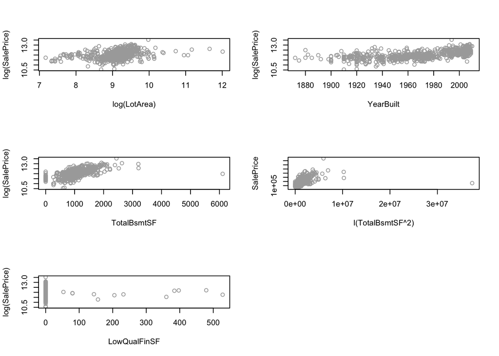

```r
par(mfrow = c(3, 2))
plot(log(SalePrice) ~ log(LotArea), data = train, col = "darkgrey")
plot(log(SalePrice) ~ YearBuilt, data = train, col = "darkgrey")
plot(log(SalePrice) ~ TotalBsmtSF, data = train, col = "darkgrey")
plot(SalePrice ~ I(TotalBsmtSF ^ 2), data = train, col = "darkgrey")
plot(log(SalePrice) ~ LowQualFinSF, data = train, col = "darkgrey")
```

Based on the above plots, we add several new models.

```r
trans_mod_1 = lm(log(SalePrice) ~ . - LotArea + log(LotArea), data = train)
trans_mod_1_inter = lm(log(SalePrice) ~ (. - LotArea + log(LotArea)) ^ 2, data = train)

trans_mod_2 = lm(SalePrice ~ . - LotArea + log(LotArea) + I(TotalBsmtSF ^ 2) + I(YearBuilt ^ 2), data = train)

trans_mod_3 = lm(log(SalePrice) ~ . + I(TotalBsmtSF ^ 2) + I(YearBuilt ^ 2), data = train)

trans_mod_4 = lm(log(SalePrice) ~ . - LotArea + log(LotArea) + I(TotalBsmtSF ^ 2) + I(YearBuilt ^ 2), data = train)
```

- Right now, we have 9 candidate models in total:
  - model_add
  - model_inter
  - log_add
  - log_inter
  - trans_mod_1
  - trans_mod_1_inter
  - trans_mod_2
  - trans_mod_3
  - trans_mod_4

### Model Choosing

**(1)** In the next step, we will use BIC to choose the best model for us, and for the additive models, we will use both backward and stepwise search.

```r
n = nrow(train) # for BIC

# additive model
add_backward = step(model_add, direction = 'backward', trace = 0, k = log(n))
add_stepwise = step(lm(SalePrice ~ 1, data = train),
                   scope = SalePrice ~ LotArea + MSZoning + LotShape + OverallQual + YearBuilt + TotalBsmtSF + LowQualFinSF + BedroomAbvGr + FullBath + GarageArea, direction = 'both', trace = 0, k = log(n))

r2_1 = get_adj_r2(add_backward)
r2_2 = get_adj_r2(add_stepwise)
rmse_1 = get_loocv_rmse(add_backward)
rmse_2 = get_loocv_rmse(add_stepwise)

# interaction model
inter_backward = step(model_inter, direction = 'backward', k = log(n), trace = 0)

r2_3 = get_adj_r2(inter_backward)
rmse_3 = get_loocv_rmse(inter_backward)

# log additive model
log_add_backward = step(log_add, direction = 'backward', trace = 0, k = log(n))
log_add_stepwise = step(lm(log(SalePrice) ~ 1, data = train),
                       scope = log(SalePrice) ~ LotArea + MSZoning + LotShape + OverallQual + YearBuilt + TotalBsmtSF + LowQualFinSF + BedroomAbvGr + FullBath + GarageArea, trace = 0, direction = 'both', k = log(n))

log_r2_1 = get_adj_r2(log_add_backward)
log_r2_2 = get_adj_r2(log_add_stepwise)
log_rmse_1 = get_loocv_rmse(log_add_backward) # log response
log_rmse_2 = get_loocv_rmse(log_add_stepwise) # log response

# log interaction model
log_inter_backward = step(log_inter, direction = 'backward', trace = 0, k = log(n))

log_r2_3 = get_adj_r2(log_inter_backward)
log_rmse_3 = get_loocv_rmse(log_inter_backward) # log response

# transformation model 1
trans_1_backward = step(trans_mod_1, direction = 'backward', trace = 0, k = log(n))
trans_1_inter = step(trans_mod_1_inter, direction = 'backward', trace = 0, k = log(n))

log_r2_4 = get_adj_r2(trans_1_backward)
log_r2_5 = get_adj_r2(trans_1_inter)
log_rmse_4 = get_loocv_rmse(trans_1_backward) # log response
log_rmse_5 = get_loocv_rmse(trans_1_inter) # log response

# transformation model 2
trans_2_backward = step(trans_mod_2, direction = 'backward', trace = 0, k = log(n))

r2_4 = get_adj_r2(trans_2_backward)
rmse_4 = get_loocv_rmse(trans_2_backward)

# transformation model 3
trans_3_backward = step(trans_mod_3, direction = 'backward', trace = 0, k = log(n))

log_r2_6 = get_adj_r2(trans_3_backward)
log_rmse_6 = get_loocv_rmse(trans_3_backward) # log response

# transformation model 4
trans_4_backward = step(trans_mod_4, direction = 'backward', k = log(n), trace = 0)

log_r2_7 = get_adj_r2(trans_4_backward)
log_rmse_7 = get_loocv_rmse(trans_4_backward) # log response
```

- Since some of the models have log transformed response, the non-log model and log model cannot be compared with LOOCV_RMSE directly, we will choose the best models of each kind.

```r
# non-log model
order(c(r2_1, r2_2, r2_3, r2_4)) # sort adjusted R2
```

```
## [1] 2 1 4 3
```

```r
order(c(rmse_1, rmse_2, rmse_3, rmse_4), decreasing = TRUE) # sort LOOCV_RMSE
```

```
## [1] 4 2 1 3
```

```r
# log model
# sort adjusted R2
order(c(log_r2_1, log_r2_2, log_r2_3, log_r2_4, log_r2_5, log_r2_6, log_r2_7))
```

```
## [1] 1 2 4 6 3 7 5
```

```r
# sort LOOCV_RMSE
order(c(log_rmse_1, log_rmse_2, log_rmse_3, log_rmse_4, log_rmse_5, log_rmse_6, log_rmse_7), decreasing = TRUE)
```

```
## [1] 2 1 4 5 6 7 3
```

Based on the results above, we can find that for non-log model, the `inter_backward` model has the highest adjusted $R ^ 2$ and lowest LOOCV_RMSE. For log model, the `log_inter_backward` model has the lowest LOOCV_RMSE and `trans_1_inter` model has the highest adjusted $R ^ 2$. Since none of the log models become the best in both aspects, we also consider `trans_4_backward`. which ranks second in both aspects.

**(2)** With this four models, we will use vif to check the collinearity and summary to find the significant predictors for us. Since the results are too long, we will show them in the Appendix, not here.

```r
vif(inter_backward)
summary(inter_backward)$coef[, 'Pr(>|t|)'] < 0.05

vif(trans_4_backward)
summary(trans_4_backward)$coef[, 'Pr(>|t|)'] < 0.05

vif(trans_1_inter)
summary(trans_1_inter)$coef[, 'Pr(>|t|)'] < 0.05

vif(log_inter_backward)
summary(log_inter_backward)$coef[, 'Pr(>|t|)'] < 0.05
```

Based on the results above, we try to modify some parameters for our models to remove the collinearity problem and unnecessary predictors.

```r
inter_backward_new = lm(SalePrice ~ LotShape + OverallQual + YearBuilt + TotalBsmtSF + BedroomAbvGr + LotArea : OverallQual, data = train)

trans_4_backward_new = lm(log(SalePrice) ~ MSZoning + OverallQual + TotalBsmtSF + FullBath + GarageArea + log(LotArea) + I(TotalBsmtSF ^ 2) + I(YearBuilt ^ 2), data = train)

trans_1_inter_new = lm(log(SalePrice) ~ log(LotArea) + MSZoning + OverallQual + YearBuilt + TotalBsmtSF, data = train)

log_inter_backward_new = lm(log(SalePrice) ~ LotArea + MSZoning + LotShape + OverallQual + YearBuilt + TotalBsmtSF + GarageArea + LotArea : TotalBsmtSF, data = train)
```

Then we will use `ANOVA` to compare each new model with the previous.

```r
# inter_backward model
anova(inter_backward_new, inter_backward)[2, "Pr(>F)"]
```

```
## [1] 3.242276e-50
```

```r
# trans_4_backward model
anova(trans_4_backward_new, trans_4_backward)[2, "Pr(>F)"]
```

```
## [1] 4.269937e-08
```

```r
# trans_1_inter model
anova(trans_1_inter_new, trans_1_inter)[2, "Pr(>F)"]
```

```
## [1] 1.660737e-66
```

```r
# log_inter_backward model
anova(log_inter_backward_new, log_inter_backward)[2, "Pr(>F)"]
```

```
## [1] 5.202113e-35
```

From the results of `ANOVA`, we find that all of the four origin models are preferred instead of the new ones. So we decide not to change the models since collinearity will not affect prediction very much.

**(3)** With this three models, we will use both train and test data to calculate base RMSE to compare the log and non-log models. Also we will calculate the average error.

```r
# inter_backward model
inter_train = sqrt(mean(resid(inter_backward) ^ 2))

test_pred_1 = predict(inter_backward, newdata = test)
inter_test = sqrt(mean((test$SalePrice - test_pred_1) ^ 2))

err1 = get_avg_err(test$SalePrice, test_pred_1)

# trans_4_backward
trans_train = sqrt(mean((train$SalePrice - exp(fitted(trans_4_backward))) ^ 2))

test_pred_2 = exp(predict(trans_4_backward, newdata = test))
trans_test = sqrt(mean((test$SalePrice - test_pred_2) ^ 2))

err2 = get_avg_err(test$SalePrice, test_pred_2)

# trans_1_inter
trans_inter_train = sqrt(mean((train$SalePrice - exp(fitted(trans_1_inter))) ^ 2))

test_pred_3 = exp(predict(trans_1_inter, newdata = test))
trans_inter_test = sqrt(mean((test$SalePrice - test_pred_3) ^ 2))

err3 = get_avg_err(test$SalePrice, test_pred_3)

trans_inter_train = sqrt(mean((train$SalePrice - exp(fitted(log_inter_backward))) ^ 2))

# log_inter_backward
log_inter_train = sqrt(mean((train$SalePrice - exp(fitted(log_inter_backward))) ^ 2))

test_pred_4 = exp(predict(log_inter_backward, newdata = test))
log_inter_test = sqrt(mean((test$SalePrice - test_pred_4) ^ 2))

err4 = get_avg_err(test$SalePrice, test_pred_4)

# create a table to compare the result
result = data.frame('inter_model' = c('train' = inter_train, 'test' = inter_test, 'avg error' = err1), 'trans_4_model' = c('train' = trans_train, 'test' = trans_test, 'avg error' = err2), 'trans_inter_model' = c('train' = trans_inter_train, 'test' = trans_inter_test, 'avg error' = err3), 'log_inter_model' = c('train' = log_inter_train, 'test' = log_inter_test, 'avg error' = err4))

kable(result, digits = 5) %>%
  kable_styling(bootstrap_options = c("striped", "hover"))
```

|  | inter_model | trans_4_model | trans_inter_model | log_inter_model |
| --- | --- | --- | --- | --- |
| train | 37641.90989 | 37049.57863 | 37532.44582 | 37532.44582 |
| test | 45453.18809 | 42533.82875 | 43306.10411 | 43055.43189 |
| avg error | 0.16059 | 0.15019 | 0.15081 | 0.15206 |

From the table above, we can see that the `trans_4_backward` model has the lowest test RMSE, the best train RMSE as well as the lowest average error. It is the best model in any aspects.

Therefore, we prefer to choose the `trains_4_backward` model as our result.

## Model Diagnostics

**(1)** After selecting the preferred model, we are going to verify the model assumptions.

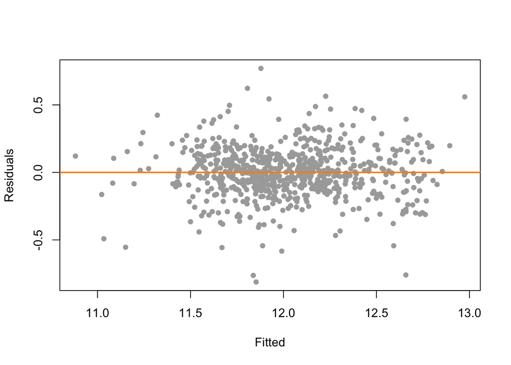

```r
plot_fitted_resid(trans_4_backward)
```

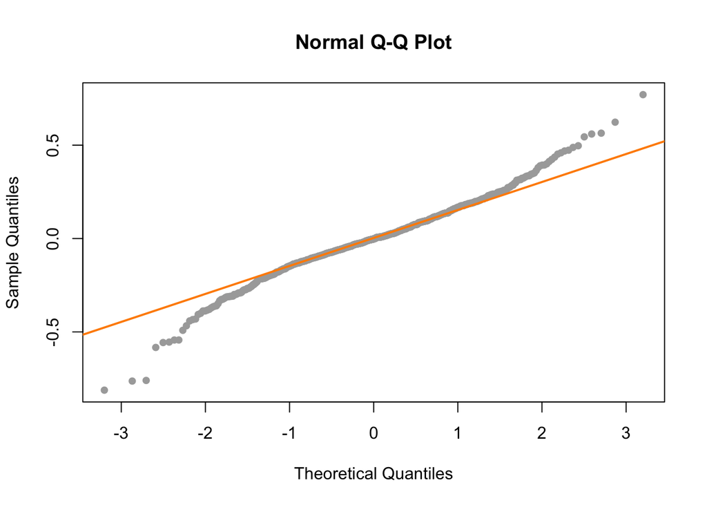

```r
plot_qq(trans_4_backward)
```

From the `fitted vs residual` plot and `Q-Q plot`, it seems that the constant variance and normality assumptions are a little suspect.

```r
get_sw_decision(trans_4_backward)
```

```
## [1] "Reject"
```

```r
get_bp_decision(trans_4_backward)
```

```
## [1] "Reject"
```

And also, Breusch-Pagan Test and Shapiro Wilk Test verify the violation of assumptions, they both reject the null under $\alpha = 0.05$.

**(2)** To fix the problem, we first try to remove the high influential observations.

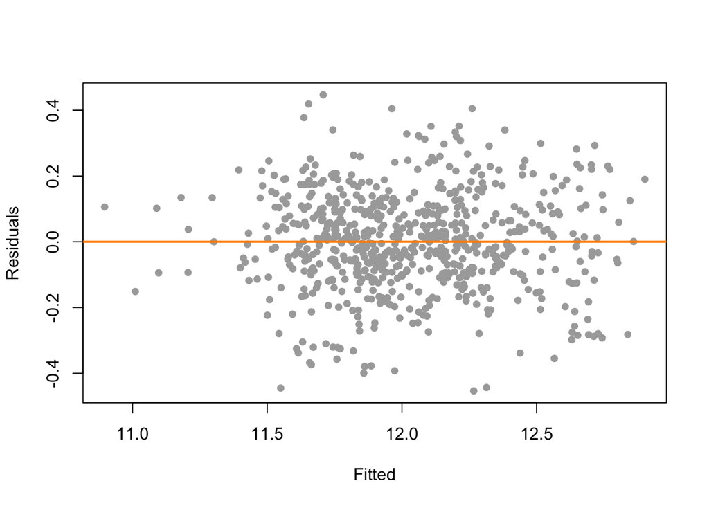

```r
# Cook's Distance
cd_trans_model = cooks.distance(trans_4_backward)

model_fix = lm(log(SalePrice) ~ MSZoning + LotShape + OverallQual + YearBuilt + TotalBsmtSF + BedroomAbvGr + FullBath + GarageArea + log(LotArea) + I(TotalBsmtSF ^ 2) + I(YearBuilt ^ 2), data = train, subset = cd_trans_model <= 4 / length(cd_trans_model))

# check the new model again
plot_fitted_resid(model_fix)
```

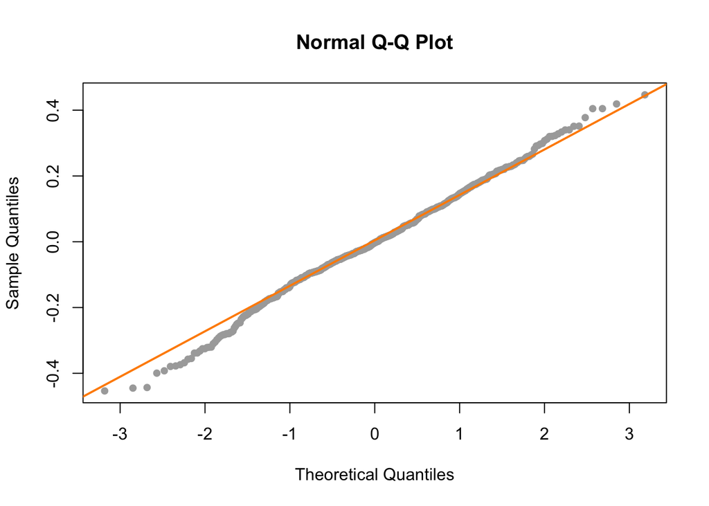

```r
plot_qq(model_fix)
```

```r
get_sw_decision(model_fix)
```

```
## [1] "Reject"
```

```r
get_bp_decision(model_fix)
```

```
## [1] "Reject"
```

From the two plots, we can see that they look really much better than before, although it still cannot pass the two assumption tests.

**(3)** For the next step, we try to use Box-Cox transformations to see if it will work.

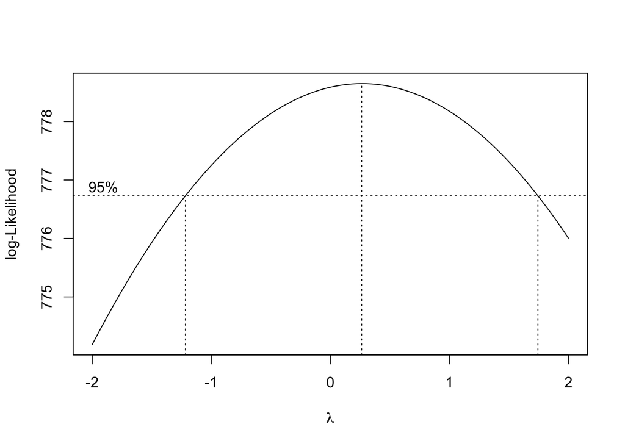

```r
boxcox(model_fix, plotit = TRUE)
```

From the plot, we can see that $\lambda = 0$ is in the interval and very close to the maximum, it means that our fixed model is good enough for Box-Cox method, but we still try to use the maximum to see if the transformation can pass the assumption tests. We will use $\lambda = 0.25$.

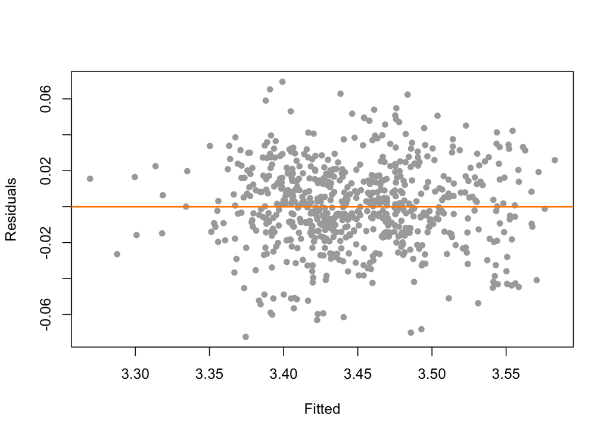

```r
model_boxcox = lm((((log(SalePrice)) ^ 0.25 - 1) / 0.25) ~ MSZoning + LotShape + OverallQual + YearBuilt + TotalBsmtSF + BedroomAbvGr + FullBath + GarageArea + log(LotArea) + I(TotalBsmtSF ^ 2) + I(YearBuilt ^ 2), data = train, subset = cd_trans_model <= 4 / length(cd_trans_model))

# check the new model
plot_fitted_resid(model_boxcox)
```

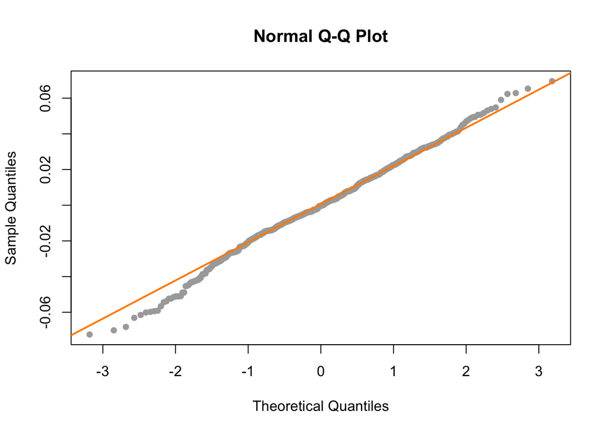

```r
plot_qq(model_boxcox)
```

```r
get_sw_decision(model_boxcox)
```

```
## [1] "Reject"
```

```r
get_bp_decision(model_boxcox)
```

```
## [1] "Reject"
```

The new model still cannot pass the test, but we can find that the fitted vs residuals plot seems a little better.

**(4)** We will get the p-value of sw test and bp test directly to see how far the two models are from not violating the assumptions.

```r
# previous fixed model
shapiro.test(resid(model_fix))$p.value
```

```
## [1] 0.04039309
```

```r
bptest(model_fix)$p.value
```

```
##         BP
## 0.01888758
```

```r
# Box-Cox model
shapiro.test(resid(model_boxcox))$p.value
```

```
## [1] 0.02476447
```

```r
bptest(model_boxcox)$p.value
```

```
##         BP
## 0.02744914
```

We could see that although the two fixed models could not pass the tests, but their p-values are not that small, actually they could be accepted if we use a smaller $\alpha$ level. And since we just want to get the model for prediction, if the accuracy is high enough, we would consider they are acceptable.

# Result

From the section above, we have chosen the model with following coefficients as our final model.

```r
names(coef(trans_4_backward))
```

```
##  [1] "(Intercept)"          "MSZoningFV"           "MSZoningRH"
##  [4] "MSZoningRL"           "MSZoningRM"           "LotShapeIR2"
##  [7] "LotShapeIR3"          "LotShapeReg"          "OverallQualexcellent"
## [10] "OverallQualpoor"      "YearBuilt"            "TotalBsmtSF"
## [13] "BedroomAbvGr"         "FullBath"             "GarageArea"
## [16] "log(LotArea)"         "I(TotalBsmtSF^2)"     "I(YearBuilt^2)"
```

The model expression is:
$$\begin{align*}
\hat{SalePrcie} = &\beta_0 + \beta_1X_{MSZoningFV} + \beta_2X_{MSZoningRH} +
\beta_3X_{MSZoningRL} + \beta_4X_{MSZoningRM} + \beta_5X_{LotShapeIR2} +
\beta_6X_{LotShapeIR3} + \beta_7X_{LotShapeReg}\\
&+ \beta_8X_{OverallQualexcellent} + \beta_9X_{OverallQualpoor} + \beta_{10}X_{YearBuilt} + \beta_{11}X_{TotalBsmtSF} + \beta_{12}X_{BedroomAbvGr} + \beta_{13}X_{FullBath} + \beta_{14}X_{GarageArea}\\
&+ \beta_{15}X_{log(LotArea)} + \beta_{16}X_{TotalBsmtSF^2} + \beta_{17}X_{YearBuilt^2}
\end{align*}$$

In the end, we also want to know the accuracy of our model after modifying.

```r
# model removing influential observations
test_1 = exp(predict(model_fix, newdata = test))
RMSE_1 = sqrt(mean((test$SalePrice - test_1) ^ 2))
error_1 = get_avg_err(test$SalePrice, test_1)

# Box-Cox model
test_2 = exp((predict(model_boxcox, newdata = test) * 0.25 + 1) ^ (1 / 0.25))
RMSE_2 = sqrt(mean((test$SalePrice - test_2) ^ 2))
error_2 = get_avg_err(test$SalePrice, test_2)

# create the table to show result
result = data.frame(model_influential = c('test_RMSE' = RMSE_1, 'avg error' = error_1), model_boxcox = c('test_RMSE' = RMSE_2, 'avg error' = error_2))

kable(result, digits = 5) %>%
  kable_styling(bootstrap_options = c("striped", "hover"))
```

|  | model_influential | model_boxcox |
| --- | --- | --- |
| test_RMSE | 42483.91367 | 42460.56051 |
| avg error | 0.14889 | 0.14922 |

The average error seems good, while test RMSE seems a bit large, we will talk about this in next section.

# Discussion

## Model Interpretion

From the sections above, we can find that our final model uses all the predictors chosen in our data set except `LowQualFinSF`, which representing the low quality square feet.

```r
head(train$LowQualFinSF, 10)
```

```
##  [1] 0 0 0 0 0 0 0 0 0 0
```

```r
mean(train$LowQualFinSF == 0)
```

```
## [1] 0.9835616
```

After taking a glance at the `LowQualFinSF` data, we find almost all of the `LowQualFinSF` data are 0 so it’s not a significant variable, this is why we do not use it as a predictor.

In this model, we use log tranformation to the response `SalePrice` and `LotArea`, and polynomial to `TotalBsmtSF` and `YearBuilt`, all of these transformations are from their distributions with `SalePrice` to make their relationship more linearly.

## Model Accuracy

From above sections, we can see the average errors of our fixed models are lower than **15%**, which indicates they are reliable for prediction.

And also, the test RMSEs are around 40000, which is seemingly a large value, we may want to discover why.

```r
summary(data_raw$SalePrice)
```

```
##    Min. 1st Qu.  Median    Mean 3rd Qu.    Max.
##   34900  129975  163000  180921  214000  755000
```

From the summary of `SalePrice`, we could find its unit is dollar, so there is no wonder that the RMSE is a big value since the sale prices are all big values in dollar.

Therefore, the accuracy of our model is acceptable.

And also, since we have omitted a large amount of attributes when we imported the data, the currently acceptable average error and difference shows that at least we are on the right way with fewer attributes, and we can add more attributes later to fit more complicated model with similar process to improve the accuracy.

## Conclusion

**In conclusion, our model is acceptable for prediction after removing influential observations or using Box-Cox tranforamtion. Although there still exists error, the error is in acceptable range. And later we can add more attributes that we did not use in this project to get more accurate model in similar methods. And right now we could rely on the current model for a rough estimation for our dream house!**

**We believe that the estimations for the ordinary houses are reliable while we would better not use it for the house which looks like extremely special from others since the we removed the influential observations when modifying the model so that our model may not useful for those special houses.**

# Appendix

When we want to discover the relationship between each variables to consider the transformation, we use `pairs` function.

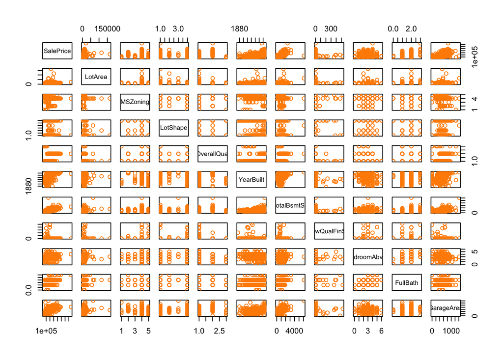

```r
pairs(train, col = "darkorange")
```

When we tried to eliminate the collinearity and select significant parameters in model selection section, we have hidden the result to make the document neater.

```r
vif(inter_backward)
```

```
##                      LotArea         OverallQualexcellent
##                    28.933143                     9.519437
##              OverallQualpoor                    YearBuilt
##                     7.403240                    13.935163
##                  TotalBsmtSF                 BedroomAbvGr
##                     3.021892                     1.328995
##                     FullBath                   GarageArea
##                  5827.916633                     1.812302
## LotArea:OverallQualexcellent      LotArea:OverallQualpoor
##                    12.412062                     7.422529
##          LotArea:TotalBsmtSF             LotArea:FullBath
##                    12.520348                    34.594888
##           YearBuilt:FullBath
##                  6062.791129
```

```r
summary(inter_backward)$coef[, 'Pr(>|t|)'] < 0.05
```

```
##                  (Intercept)                      LotArea
##                         TRUE                        FALSE
##         OverallQualexcellent              OverallQualpoor
##                        FALSE                        FALSE
##                    YearBuilt                  TotalBsmtSF
##                         TRUE                         TRUE
##                 BedroomAbvGr                     FullBath
##                         TRUE                         TRUE
##                   GarageArea LotArea:OverallQualexcellent
##                         TRUE                         TRUE
##      LotArea:OverallQualpoor          LotArea:TotalBsmtSF
##                         TRUE                         TRUE
##             LotArea:FullBath           YearBuilt:FullBath
##                         TRUE                         TRUE
```

```r
vif(trans_4_backward)
```

```
##           MSZoningFV           MSZoningRH           MSZoningRL
##            10.780805             3.071852            34.368191
##           MSZoningRM          LotShapeIR2          LotShapeIR3
##            26.116373             1.095089             1.240491
##          LotShapeReg OverallQualexcellent      OverallQualpoor
##             1.222192             1.600579             1.093085
##            YearBuilt          TotalBsmtSF         BedroomAbvGr
##         20120.917759             4.888550             1.365396
##             FullBath           GarageArea         log(LotArea)
##             1.870735             1.763282             1.768067
##     I(TotalBsmtSF^2)       I(YearBuilt^2)
##             4.392658         20213.413150
```

```r
summary(trans_4_backward)$coef[, 'Pr(>|t|)'] < 0.05
```

```
##          (Intercept)           MSZoningFV           MSZoningRH
##                 TRUE                 TRUE                 TRUE
##           MSZoningRL           MSZoningRM          LotShapeIR2
##                 TRUE                 TRUE                FALSE
##          LotShapeIR3          LotShapeReg OverallQualexcellent
##                FALSE                 TRUE                 TRUE
##      OverallQualpoor            YearBuilt          TotalBsmtSF
##                 TRUE                 TRUE                 TRUE
##         BedroomAbvGr             FullBath           GarageArea
##                 TRUE                 TRUE                 TRUE
##         log(LotArea)     I(TotalBsmtSF^2)       I(YearBuilt^2)
##                 TRUE                 TRUE                 TRUE
```

```r
vif(trans_1_inter)
```

```
##             MSZoningFV             MSZoningRH             MSZoningRL
##              10.890018               3.082118              34.447809
##             MSZoningRM            LotShapeIR2            LotShapeIR3
##              26.283995               1.097001               1.219802
##            LotShapeReg   OverallQualexcellent        OverallQualpoor
##               1.231683               1.698717               1.112042
##              YearBuilt            TotalBsmtSF           BedroomAbvGr
##              23.481843               5.898998            4902.216194
##               FullBath             GarageArea           log(LotArea)
##            7398.705743            5267.706894               1.800835
## YearBuilt:BedroomAbvGr     YearBuilt:FullBath   YearBuilt:GarageArea
##            4881.407079            7738.613816            5567.763254
## TotalBsmtSF:GarageArea
##              11.022039
```

```r
summary(trans_1_inter)$coef[, 'Pr(>|t|)'] < 0.05
```

```
##            (Intercept)             MSZoningFV             MSZoningRH
##                   TRUE                   TRUE                   TRUE
##             MSZoningRL             MSZoningRM            LotShapeIR2
##                   TRUE                   TRUE                  FALSE
##            LotShapeIR3            LotShapeReg   OverallQualexcellent
##                  FALSE                   TRUE                   TRUE
##        OverallQualpoor              YearBuilt            TotalBsmtSF
##                   TRUE                  FALSE                   TRUE
##           BedroomAbvGr               FullBath             GarageArea
##                   TRUE                   TRUE                   TRUE
##           log(LotArea) YearBuilt:BedroomAbvGr     YearBuilt:FullBath
##                   TRUE                   TRUE                   TRUE
##   YearBuilt:GarageArea TotalBsmtSF:GarageArea
##                   TRUE                   TRUE
```

```r
vif(log_inter_backward)
```

```
##                LotArea             MSZoningFV             MSZoningRH
##               3.995598              10.802606               3.057786
##             MSZoningRL             MSZoningRM            LotShapeIR2
##              34.084068              26.082616               1.100722
##            LotShapeIR3            LotShapeReg   OverallQualexcellent
##               1.217962               1.208114               1.543099
##        OverallQualpoor              YearBuilt            TotalBsmtSF
##               1.104747              20.374576               2.950392
##           BedroomAbvGr               FullBath             GarageArea
##            4833.004321            7186.690107               1.661231
##    LotArea:TotalBsmtSF YearBuilt:BedroomAbvGr     YearBuilt:FullBath
##               5.881678            4808.450704            7512.387650
```

```r
summary(log_inter_backward)$coef[, 'Pr(>|t|)'] < 0.05
```

```
##            (Intercept)                LotArea             MSZoningFV
##                   TRUE                   TRUE                   TRUE
##             MSZoningRH             MSZoningRL             MSZoningRM
##                   TRUE                   TRUE                   TRUE
##            LotShapeIR2            LotShapeIR3            LotShapeReg
##                  FALSE                  FALSE                   TRUE
##   OverallQualexcellent        OverallQualpoor              YearBuilt
##                   TRUE                   TRUE                  FALSE
##            TotalBsmtSF           BedroomAbvGr               FullBath
##                   TRUE                   TRUE                   TRUE
##             GarageArea    LotArea:TotalBsmtSF YearBuilt:BedroomAbvGr
##                   TRUE                   TRUE                   TRUE
##     YearBuilt:FullBath
##                   TRUE
```